# Assignment - 13th June, 2019

```python
import pandas as pd
import numpy as np
import matplotlib.pyplot as plt
plt.style.use('ggplot')
```

```python
df = pd.read_csv('data.csv')
df.drop(['time_period','time_period_type'],axis = 1,inplace = True)
```

```python
df.head()
```

|  | report_date | location | location_type | data_field | data_field_code | value | unit |
| --- | --- | --- | --- | --- | --- | --- | --- |
| 0 | 2016-03-19 | Argentina-Buenos_Aires | province | cumulative_confirmed_local_cases | AR0001 | 0 | cases |
| 1 | 2016-03-19 | Argentina-Buenos_Aires | province | cumulative_probable_local_cases | AR0002 | 0 | cases |
| 2 | 2016-03-19 | Argentina-Buenos_Aires | province | cumulative_confirmed_imported_cases | AR0003 | 2 | cases |
| 3 | 2016-03-19 | Argentina-Buenos_Aires | province | cumulative_probable_imported_cases | AR0004 | 1 | cases |
| 4 | 2016-03-19 | Argentina-Buenos_Aires | province | cumulative_cases_under_study | AR0005 | 127 | cases |

```python
df.describe()
```

|  | report_date | location | location_type | data_field | data_field_code | value | unit |
| --- | --- | --- | --- | --- | --- | --- | --- |
| count | 107612 | 107612 | 107612 | 107612 | 107612 | 107481 | 107612 |
| unique | 128 | 1673 | 11 | 148 | 153 | 1749 | 2 |
| top | 2016-04-23 | United_States_Virgin_Islands | municipality | zika_suspected | CO0001 | 0 | cases |
| freq | 4677 | 413 | 87557 | 28963 | 28963 | 45134 | 106519 |

```python
df.dtypes
```

```
report_date        object
location           object
location_type      object
data_field         object
data_field_code    object
value              object
unit               object
dtype: object
```

## 1. show data field code 'AR0005' values for 'Argentina-Catamarca' for entire duration

```python
s_df = df[(df.location == 'Argentina-Catamarca') & (df.data_field_code == 'AR0005')]
s_df['value'] = pd.to_numeric(s_df['value'])
s_df
```

|  | report_date | location | location_type | data_field | data_field_code | value | unit |
| --- | --- | --- | --- | --- | --- | --- | --- |
| 16 | 2016-03-19 | Argentina-Catamarca | province | cumulative_cases_under_study | AR0005 | 14 | cases |
| 160 | 2016-03-26 | Argentina-Catamarca | province | cumulative_cases_under_study | AR0005 | 15 | cases |
| 304 | 2016-04-02 | Argentina-Catamarca | province | cumulative_cases_under_study | AR0005 | 15 | cases |
| 448 | 2016-04-09 | Argentina-Catamarca | province | cumulative_cases_under_study | AR0005 | 15 | cases |
| 592 | 2016-04-16 | Argentina-Catamarca | province | cumulative_cases_under_study | AR0005 | 15 | cases |
| 736 | 2016-04-29 | Argentina-Catamarca | province | cumulative_cases_under_study | AR0005 | 15 | cases |
| 880 | 2016-05-07 | Argentina-Catamarca | province | cumulative_cases_under_study | AR0005 | 16 | cases |
| 1024 | 2016-05-14 | Argentina-Catamarca | province | cumulative_cases_under_study | AR0005 | 15 | cases |
| 1168 | 2016-05-22 | Argentina-Catamarca | province | cumulative_cases_under_study | AR0005 | 16 | cases |
| 1312 | 2016-05-30 | Argentina-Catamarca | province | cumulative_cases_under_study | AR0005 | 15 | cases |
| 1456 | 2016-06-06 | Argentina-Catamarca | province | cumulative_cases_under_study | AR0005 | 15 | cases |
| 1600 | 2016-06-13 | Argentina-Catamarca | province | cumulative_cases_under_study | AR0005 | 15 | cases |
| 1744 | 2016-06-18 | Argentina-Catamarca | province | cumulative_cases_under_study | AR0005 | 15 | cases |
| 1888 | 2016-06-26 | Argentina-Catamarca | province | cumulative_cases_under_study | AR0005 | 16 | cases |

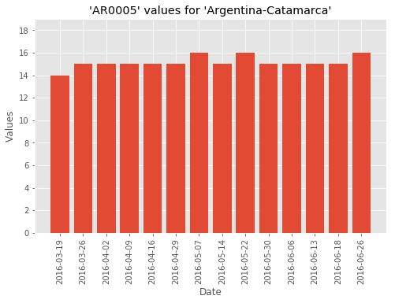

```python
plt.figure(figsize=(8,5))
ax = plt.bar(s_df.report_date,s_df.value)
plt.xticks(rotation=90)
plt.yticks(np.arange(0, 20, step=2))
plt.ylim([0,19])
plt.ylabel("Values")
plt.xlabel("Date")
plt.title("'AR0005' values for 'Argentina-Catamarca'")
```

## 2. Plot 'Argentina-CABA' and 'Argentina-Catamarca' for number of cases values for entire duration to identify the difference.

### HINT : Plot sum of the 'value' where 'units' = 'cases' to identify the difference for the locations 'Argentina-CABA' and 'Argentina-Catamarca' for entire duration.

```python
plt_df = df[(df.location == 'Argentina-CABA') | (df.location == 'Argentina-Catamarca') & (df.unit == 'cases')]
```

```python
plt_df.head()
```

|  | report_date | location | location_type | data_field | data_field_code | value | unit |
| --- | --- | --- | --- | --- | --- | --- | --- |
| 6 | 2016-03-19 | Argentina-CABA | province | cumulative_confirmed_local_cases | AR0001 | 0 | cases |
| 7 | 2016-03-19 | Argentina-CABA | province | cumulative_probable_local_cases | AR0002 | 0 | cases |
| 8 | 2016-03-19 | Argentina-CABA | province | cumulative_confirmed_imported_cases | AR0003 | 9 | cases |
| 9 | 2016-03-19 | Argentina-CABA | province | cumulative_probable_imported_cases | AR0004 | 0 | cases |
| 10 | 2016-03-19 | Argentina-CABA | province | cumulative_cases_under_study | AR0005 | 68 | cases |

```python
plt_df.describe()
```

|  | report_date | location | location_type | data_field | data_field_code | value | unit |
| --- | --- | --- | --- | --- | --- | --- | --- |
| count | 168 | 168 | 168 | 168 | 168 | 168 | 168 |
| unique | 14 | 2 | 1 | 6 | 6 | 21 | 1 |
| top | 2016-06-13 | Argentina-Catamarca | province | cumulative_confirmed_imported_cases | AR0006 | 0 | cases |
| freq | 12 | 84 | 168 | 28 | 28 | 112 | 168 |

```python
plt_df['value'] = pd.to_numeric(plt_df['value'])
plt_df.report_date = plt_df.report_date.apply(lambda x: x[:-3])
```

## Bar Graph showing total cases registered in a month for different provinces

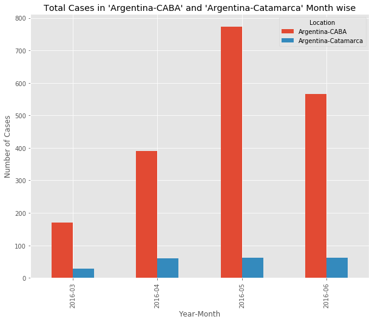

```python
d1 = plt_df[plt_df.location == 'Argentina-CABA'].groupby('report_date').sum()
d2 = plt_df[plt_df.location == 'Argentina-Catamarca'].groupby('report_date').sum()
d1.columns = ['Argentina-CABA']
d2.columns = ['Argentina-Catamarca']
ax = d1.join(d2).plot(kind = 'bar',figsize=(10,8),title="Total Cases in 'Argentina-CABA' and 'Argentina-Catamarca' Month wise")
ax.set(xlabel="Year-Month", ylabel="Number of Cases")
plt.legend(title = 'Location')
```

## Bar Graph depicting number of cases in both provinces for various types of cases

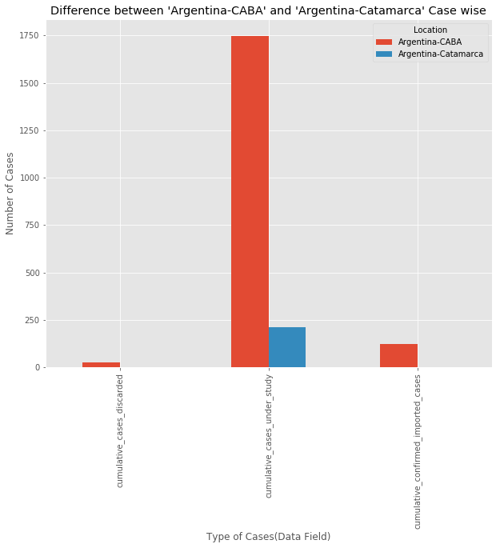

```python
d1 = plt_df[plt_df.location == 'Argentina-CABA'].groupby('data_field').sum()
d2 = plt_df[plt_df.location == 'Argentina-Catamarca'].groupby('data_field').sum()
d1 = d1[d1.value>0]
d1.columns = ['Argentina-CABA']
d2.columns = ['Argentina-Catamarca']
ax = d1.join(d2).plot(kind = 'bar',figsize=(10,8),title="Difference between 'Argentina-CABA' and 'Argentina-Catamarca' Case wise")
ax.set(xlabel="Type of Cases(Data Field)", ylabel="Number of Cases")
plt.legend(title = 'Location')
```

## 3. Plot how data field values are distributed across the locations 'Argentina-Buenos_Aires', 'Argentina-CABA', 'Argentina-Catamarca'

```python
new_df = df[(df.location == 'Argentina-CABA') | (df.location == 'Argentina-Catamarca') | (df.location == 'Argentina-Buenos_Aires')]
```

```python
new_df.head(10)
```

|  | report_date | location | location_type | data_field | data_field_code | value | unit |
| --- | --- | --- | --- | --- | --- | --- | --- |
| 0 | 2016-03-19 | Argentina-Buenos_Aires | province | cumulative_confirmed_local_cases | AR0001 | 0 | cases |
| 1 | 2016-03-19 | Argentina-Buenos_Aires | province | cumulative_probable_local_cases | AR0002 | 0 | cases |
| 2 | 2016-03-19 | Argentina-Buenos_Aires | province | cumulative_confirmed_imported_cases | AR0003 | 2 | cases |
| 3 | 2016-03-19 | Argentina-Buenos_Aires | province | cumulative_probable_imported_cases | AR0004 | 1 | cases |
| 4 | 2016-03-19 | Argentina-Buenos_Aires | province | cumulative_cases_under_study | AR0005 | 127 | cases |
| 5 | 2016-03-19 | Argentina-Buenos_Aires | province | cumulative_cases_discarded | AR0006 | 0 | cases |
| 6 | 2016-03-19 | Argentina-CABA | province | cumulative_confirmed_local_cases | AR0001 | 0 | cases |
| 7 | 2016-03-19 | Argentina-CABA | province | cumulative_probable_local_cases | AR0002 | 0 | cases |
| 8 | 2016-03-19 | Argentina-CABA | province | cumulative_confirmed_imported_cases | AR0003 | 9 | cases |
| 9 | 2016-03-19 | Argentina-CABA | province | cumulative_probable_imported_cases | AR0004 | 0 | cases |

```python
new_df.describe()
```

|  | report_date | location | location_type | data_field | data_field_code | value | unit |
| --- | --- | --- | --- | --- | --- | --- | --- |
| count | 252 | 252 | 252 | 252 | 252 | 252 | 252 |
| unique | 14 | 3 | 1 | 6 | 6 | 42 | 1 |
| top | 2016-05-07 | Argentina-Catamarca | province | cumulative_confirmed_imported_cases | AR0006 | 0 | cases |
| freq | 18 | 84 | 252 | 42 | 42 | 142 | 252 |

```python
new_df['value'] = pd.to_numeric(new_df['value'])
```

## Distribution of Cases within a Province

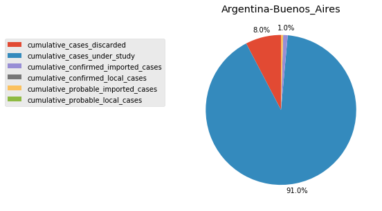

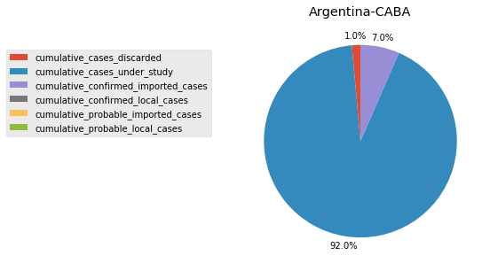

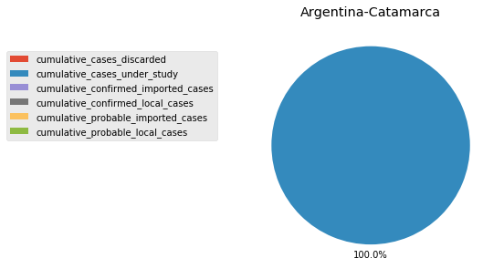

```python
for loc in new_df.location.unique():
    gp = new_df[new_df.location == loc].groupby('data_field').sum()
    ax = gp.plot(kind = 'pie',y = 'value',figsize = (8,5),labels = None,startangle = 90,autopct=lambda p: '{:.1f}%'.format(round(p)) if p > 0.9 else '',pctdistance = 1.1)
    plt.legend(labels=gp.index,loc='best', bbox_to_anchor=(-0.1, 0.9),fontsize=10)
    plt.title(loc)
    plt.axes().set_ylabel('')
```

## Bar Graph depicting number of cases in different provinces for various types of cases

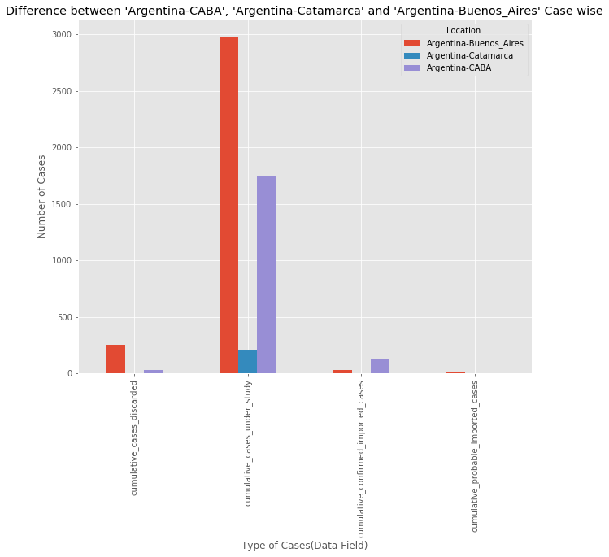

```python
d1 = new_df[new_df.location == 'Argentina-CABA'].groupby('data_field').sum()
d2 = new_df[new_df.location == 'Argentina-Catamarca'].groupby('data_field').sum()
d3 = new_df[new_df.location == 'Argentina-Buenos_Aires'].groupby('data_field').sum()
d3 = d3[d3.value>0]
d1.columns = ['Argentina-CABA']
d2.columns = ['Argentina-Catamarca']
d3.columns = ['Argentina-Buenos_Aires']
ax = d3.join(d2).join(d1).plot(kind = 'bar',figsize=(10,8),title="Difference between 'Argentina-CABA', 'Argentina-Catamarca' and 'Argentina-Buenos_Aires' Case wise")
ax.set(xlabel="Type of Cases(Data Field)", ylabel="Number of Cases")
plt.legend(title = 'Location')
```

## Pie Chart showing provinces affected by various types of cases

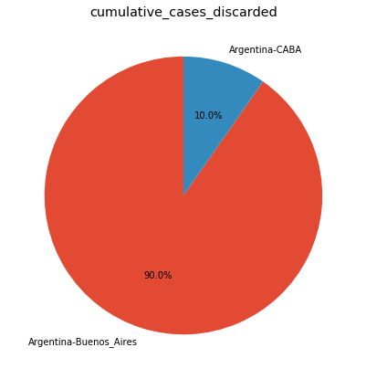

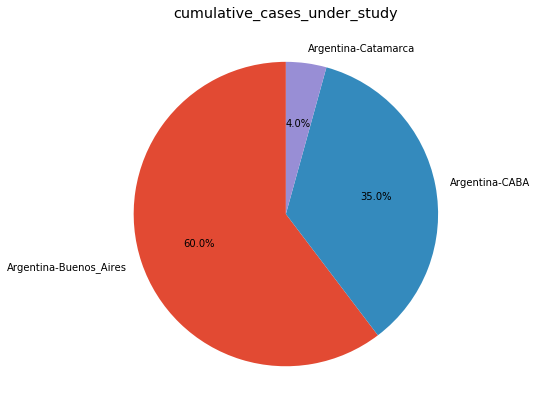

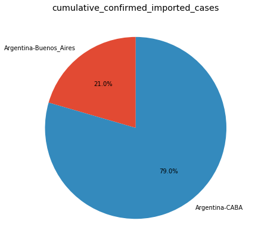

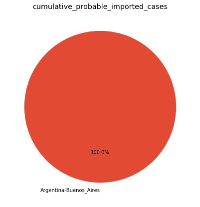

```python
for case_type,grp in new_df.groupby('data_field'):
    gp = grp.groupby('location').sum()
    if(sum(gp.value)):
        gp.plot(kind = 'pie',subplots = True,autopct=lambda p: '{:.1f}%'.format(round(p)) if p > 0 else '',startangle = 90,figsize = (7,7))
        plt.title(case_type,y = 1.0)
        plt.axes().set_ylabel('')
        plt.axes().get_legend().remove()
```

## 4. Build a program to predict the correct word for wrongly typed word. for example whst => what, numbr =>number, good => good

Hint : identify most common mistakes that can occur during typing and use big text corpus(big.txt)

#### Slower method of forming a dictionary

```python
# import string
# import re

# f = open("big.txt")
# dict_all = {}
# space=" "
# for i in range(len(string.punctuation)-1):
#    space+=" "
# text = f.read()
# f.close()
# text = text.lower()
# text = re.sub(r'\d', ' ', text)
# table = str.maketrans(string.punctuation, space)
# text=text.translate(table)
# words = text.split()
# for w in set(words):
#     dict_all[w] = words.count(w)

# sorted(dict_all.items(), key=lambda item: item[1])
```

## Implementation of Norvig Search Algorithm

### Faster method of forming the dictionary

```python
import re
from collections import Counter
import math
```

```python
with open('big.txt') as f:
    text = f.read()
    ctr = re.findall(r'\w+', text.lower())
    dict_words = Counter(ctr)
dict_words.most_common(24)
```

```
[('the', 79809),
 ('of', 40024),
 ('and', 38312),
 ('to', 28765),
 ('in', 22023),
 ('a', 21124),
 ('that', 12512),
 ('he', 12401),
 ('was', 11410),
 ('it', 10681),
 ('his', 10034),
 ('is', 9773),
 ('with', 9739),
 ('as', 8064),
 ('i', 7684),
 ('had', 7383),
 ('for', 6941),
 ('at', 6789),
 ('by', 6735),
 ('on', 6639),
 ('not', 6626),
 ('be', 6155),
 ('from', 5689),
 ('but', 5653)]
```

```python
total_words = sum(dict_words.values())
```

### Finding Log Probability for a word

```python
def Probability(word):
    if dict_words[word]:
        return math.log(dict_words[word] / total_words)
    else:
        return float("-inf")
```

### Finding all possible correct words for the given word

```python
def all_possible_words(word):
    return (correctWord([word]) or correctWord(lev_dis1(word)) or correctWord(lev_dis2(word)) or [word])
```

### Finding all combinations of words with Levenshtein distance as 1

```python
def lev_dis1(word):
    letters    = 'abcdefghijklmnopqrstuvwxyz'
    delete,transpose,replace,insert = [],[],[],[]
    for i in range(len(word) + 1):
        pre = word[:i]
        suf = word[i:]
        if suf:
            delete.append(pre + suf[1:])
        if len(suf) > 1 :
            transpose.append(pre + suf[1] + suf[0] + suf[2:])
        for char in letters:
            insert.append(pre + char + suf)
            if suf:
                replace.append(pre + char + suf[1:])
    all_words = set(delete + transpose + insert + replace)
    return all_words
```

### Finding all combinations of words with Levenshtein distance as 2

```python
def lev_dis2(word):
    temp_words = lev_dis1(word)
    ldis2_words = set()
    for tword in temp_words:
        ldis2_words.update(lev_dis1(tword))
    return ldis2_words
```

### Finding all valid words from the set of words

```python
def correctWord(words):
    corr_word = set()
    for word in words:
        if word in dict_words:
            corr_word.add(word)
    return corr_word
```

### Function to find correct spelling if possible: returns the most probable spelling of the given word

```python
def spell_check(word):
    return max(all_possible_words(word), key=Probability)
```

### Function that corrects all spelling mistakes in a sentence

```python
def sentence_corrector(sent):
    return " ".join(list(map(spell_check,sent.strip().lower().split())))
```

### Few examples of the spell checker

```python
spell_check("blis")
```

```
'bliss'
```

```python
sentence_corrector("thiis is vrong speling")
```

```
'this is wrong spelling'
```

```python
spell_check('factry')
```

```
'factory'
```

```python
spell_check('bordom')
```

```
'boredom'
```

```python
sentence_corrector('tooday is anthrr qday')
```

```
'today is another day'
```

```python
sentence_corrector('east or wst Nagarro is teh beesst')
```

```
'east or west nagarro is the best'
```